# Homework 8

*Soultions*

For this assignment, we will use the `forecast` and `tseries` libraries.

```r
library("forecast")
library("tseries")
```

The dataset is the exchange rate for the Indian Rupee to 1 U.S. Dollar. The data is daily from July 1st, 2002 to April 8th, 2011.

```r
data <- read.csv("http://ptrckprry.com/course/forecasting/data/rupee.csv")
date <- as.Date(data$date, format="%m/%d/%Y")
time <- 1:length(date)
rupee <- data$rupee
```

We will work with the logs of the exchange rates:

```r
log.rupee <- log(rupee)
```

## Problem 1

Here is a time series plot of log.rupee, along with the ACF and PACF:

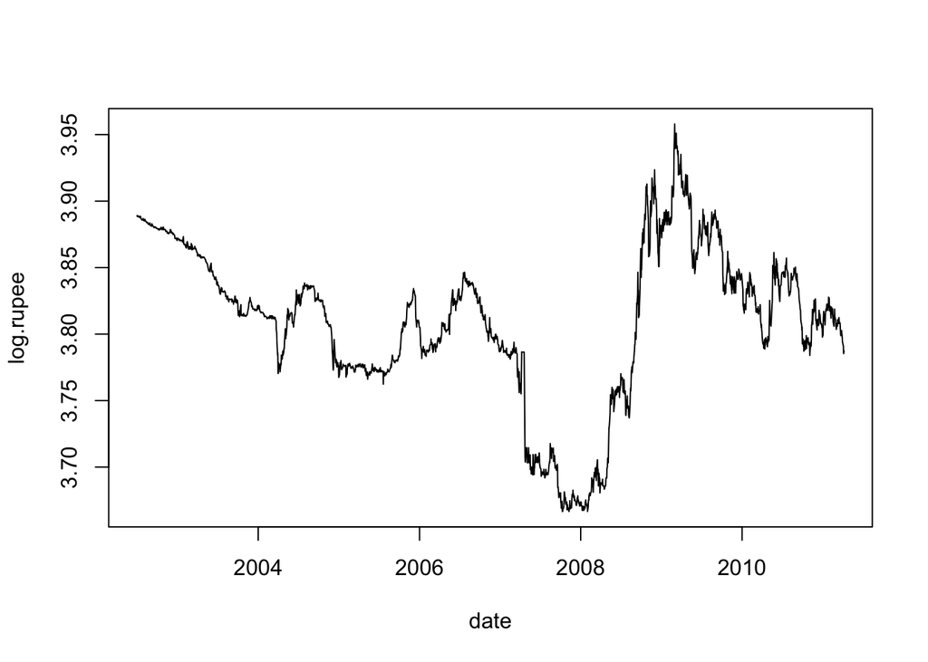

```r
plot(date, log.rupee, type="l")
```

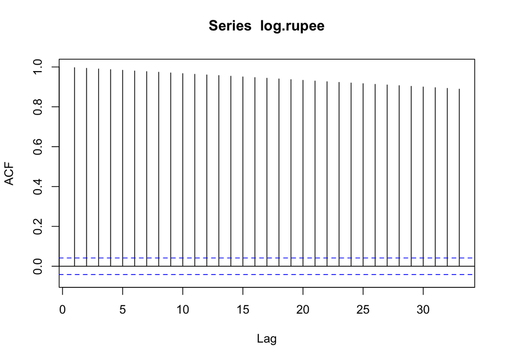

```r
Acf(log.rupee)
```

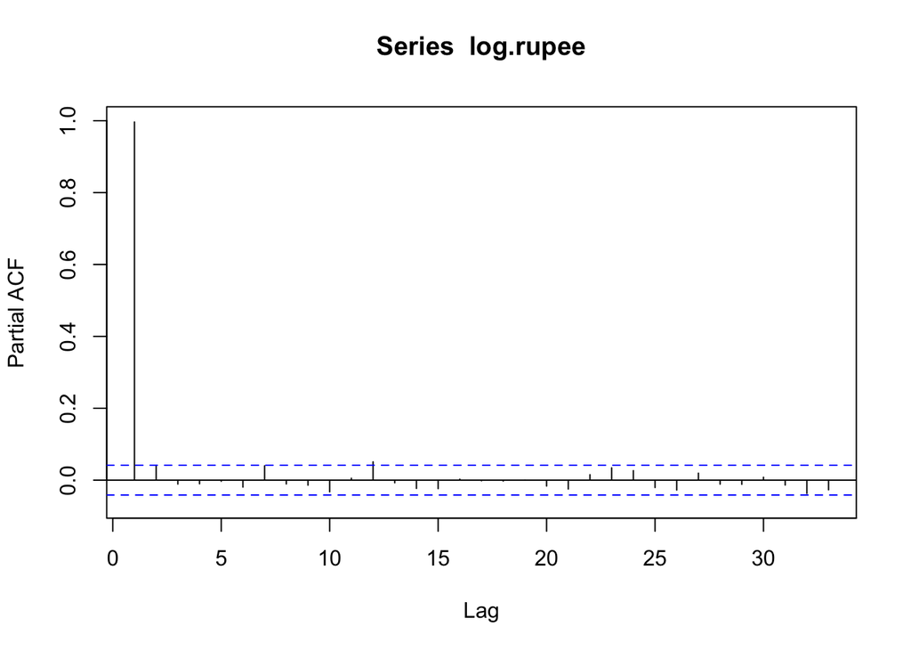

```r
Pacf(log.rupee)
```

Here is the first difference, along with the ACF and PACF:

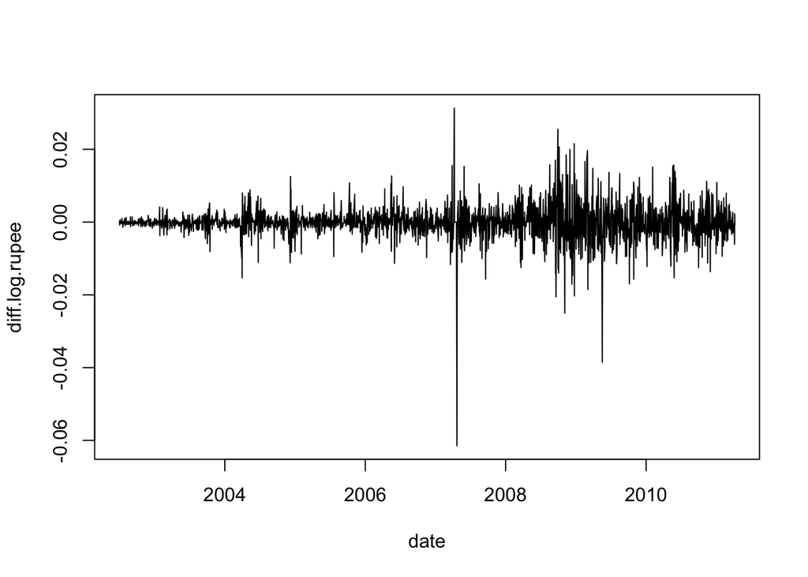

```r
diff.log.rupee <- c(NA, diff(log.rupee))
plot(date, diff.log.rupee, type="l")
```

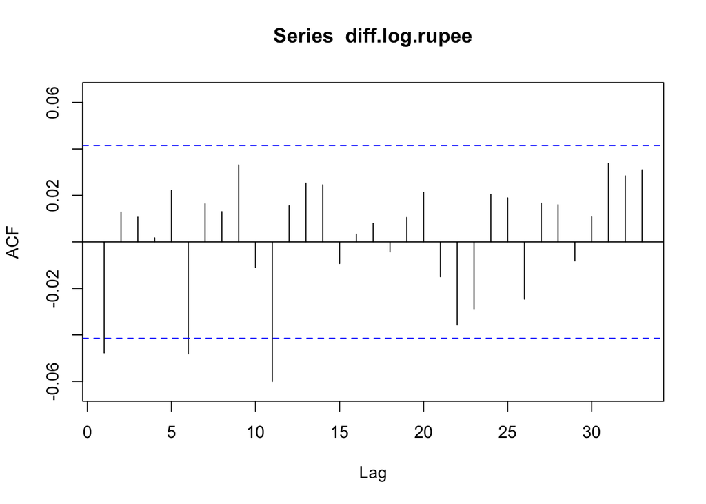

```r
Acf(diff.log.rupee)
```

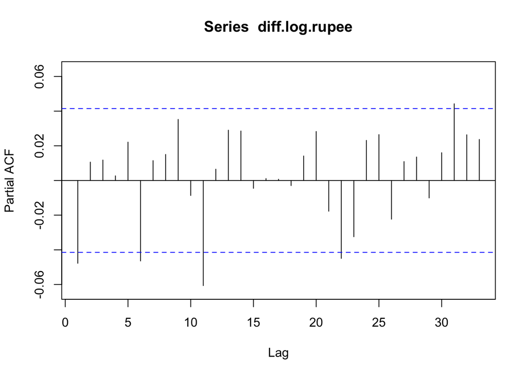

```r
Pacf(diff.log.rupee)
```

Here is the second difference, along with the ACF and PACF:

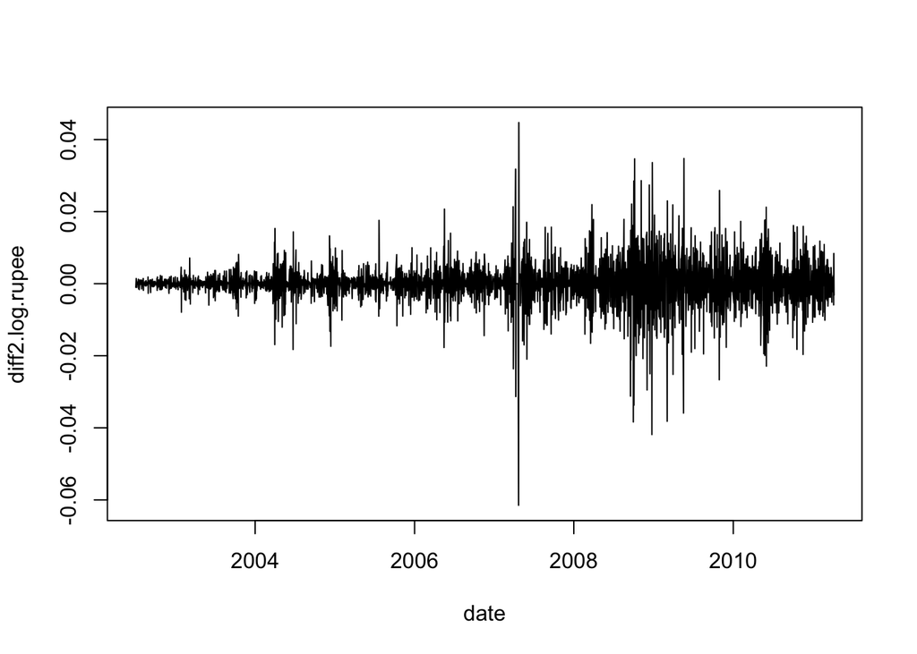

```r
diff2.log.rupee <- c(NA, diff(diff.log.rupee))
plot(date, diff2.log.rupee, type="l")
```

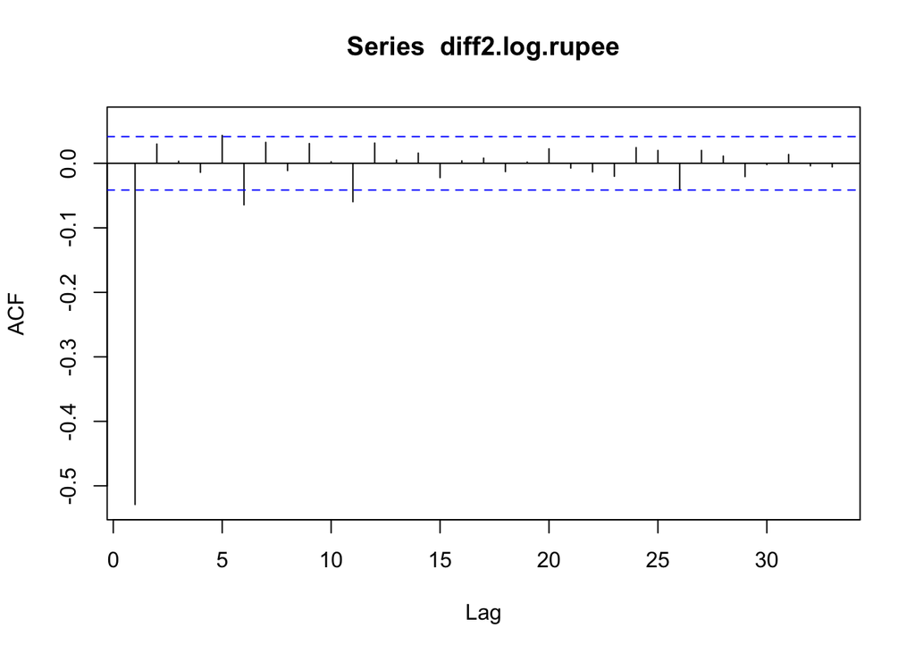

```r
Acf(diff2.log.rupee)
```

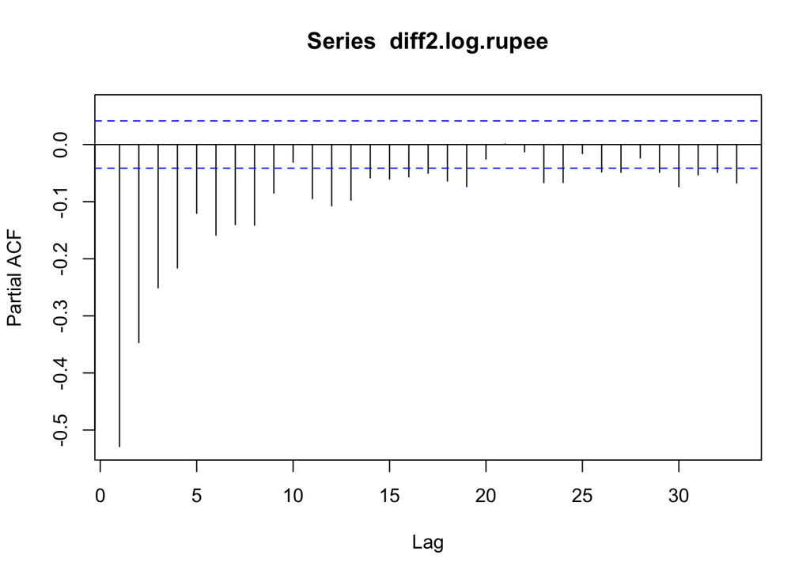

```r
Pacf(diff2.log.rupee)
```

**Does the series appear to be stationary?**

The first difference looks stationary, but not the original series.

**Can you identify an ARIMA(p,d,q) model from these plots?**

## Problem 2

Here are the AICc for all ARIMA(p,1,q) models without constant for p and q ranging from 0 to 2:

```r
# Hint: you can modify the code from
# http://ptrckprry.com/course/forecasting/lecture/nasdaq-arch.html
# if you don't want to do this by hand.

d <- 1
for (p in 0:2) {
    for (q in 0:2) {
        # manually difference to avoid bug in Arima code
        fit <- Arima(diff.log.rupee, c(p,0,q), include.constant=FALSE)
        cat("ARIMA", "(", p, ",", d, ",", q, ")",
            " : ", fit$aicc, "\n", sep="")
    }
}
```

```
## ARIMA(0,1,0) : -17760.3
## ARIMA(0,1,1) : -17763.25
## ARIMA(0,1,2) : -17761.68
## ARIMA(1,1,0) : -17763.37
## ARIMA(1,1,1) : -17761.47
## ARIMA(1,1,2) : -17759.65
## ARIMA(2,1,0) : -17761.62
## ARIMA(2,1,1) : -17759.63
## ARIMA(2,1,2) : -17757.75
```

**Select an ARIMA(p,1,q) model.**

Based on AICc, we select p = 1 and q = 0.

Here is code to fit the model, then compute residuals and the fitted values:

```r
(fit.mean <- Arima(log.rupee, c(1, 1, 0), include.constant=FALSE))
```

```
## Series: log.rupee
## ARIMA(1,1,0)
##
## Coefficients:
##           ar1
##       -0.0476
## s.e.   0.0211
##
## sigma^2 estimated as 2.06e-05:  log likelihood=8883.69
## AIC=-17763.38   AICc=-17763.37   BIC=-17751.95
```

Here are the residuals, with the last 5 residuals printed out:

```r
resid <- residuals(fit.mean)
tail(resid, n=5)
```

```
## Time Series:
## Start = 2231
## End = 2235
## Frequency = 1
## [1] -0.0025960693 -0.0003436514 -0.0061214359  0.0019765154 -0.0007984057
```

Here are the fitted values, with the last 5 fitted values printed out:

```r
f <- fitted.values(fit.mean)
tail(f, n=5)
```

```
## Time Series:
## Start = 2231
## End = 2235
## Frequency = 1
## [1] 3.794258 3.791780 3.791447 3.785616 3.787485
```

Here is the one step ahead forecast and 95% forecast interval:

```r
forecast(fit.mean, h=1, level=95)
```

```
##      Point Forecast    Lo 95    Hi 95
## 2236        3.78673 3.777834 3.795625
```

## Problem 3

Here is a plot of the residuals:

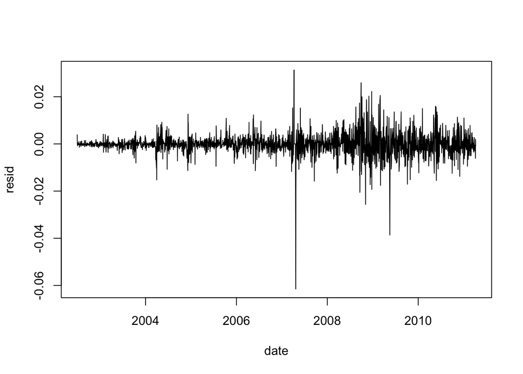

```r
plot(date, resid, type="l")
```

Here are an ACF and PACF of the residuals:

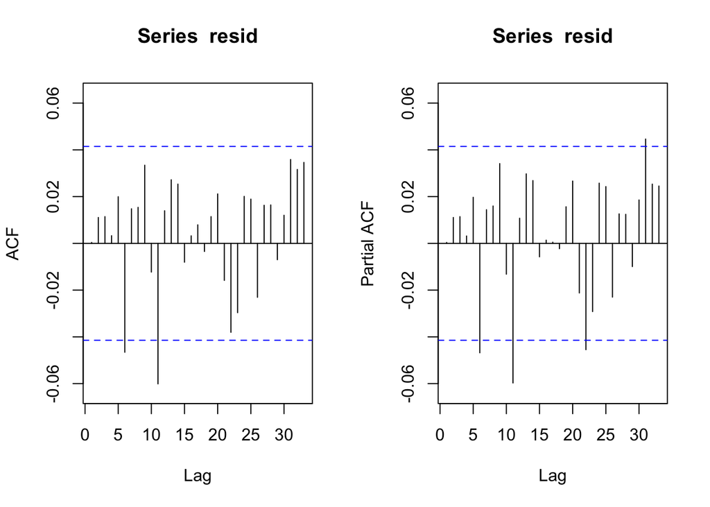

```r
par(mfrow=c(1,2))
Acf(resid)
Pacf(resid)
```

Here are an ACF and PACF of the squared residuals:

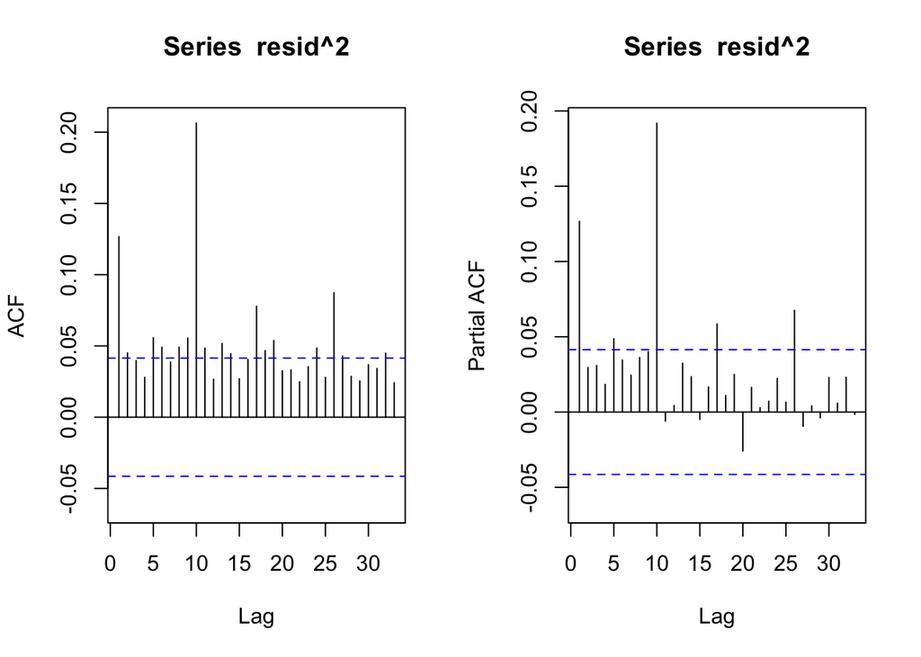

```r
par(mfrow=c(1,2))
Acf(resid^2)
Pacf(resid^2)
```

**Use these plots to argue that the residuals, although approximately uncorrelated, are not independent; instead, they show evidence of conditional heteroscedasticity.**

The ACF and PACF of the residuals show some nonzero autocorrelation, especially at lag 11, but it is very small (less than 0.07 in absolute value); the residuals are approximately uncorrelated.

From the ACF and PACF of the squared residuals, we can see noticeable correlations and partial autocorrelations at lags 1 and 10, indicating autocorrelation in the volatility. We can also see this volatility behavior in the time series plot.

## Problem 4

Here are the AICc values for the ARCH(q):

```r
q <- 0:10
loglik <- rep(NA, length(q))
N <- length(resid)

for (i in 1:length(q)) {
    if (q[i] == 0) {
        loglik[i] <- -0.5 * N * (1 + log(2 * pi * mean(resid^2)))
    } else {
        fit <- garch(resid, c(0,q[i]), trace=FALSE)
        loglik[i] <- logLik(fit)
    }
}
k <- q + 1
aicc <- -2 * loglik  + 2 * k * N / (N - k - 1)

print(data.frame(q, loglik, aicc))
```

```
##     q   loglik      aicc
## 1   0 8887.798 -17773.59
## 2   1 9000.404 -17996.80
## 3   2 9038.792 -18071.57
## 4   3 9088.392 -18168.77
## 5   4 9095.895 -18181.76
## 6   5 9105.251 -18198.46
## 7   6 9112.237 -18210.42
## 8   7 9126.493 -18236.92
## 9   8 9125.096 -18232.11
## 10  9 9121.129 -18222.16
## 11 10 9523.238 -19024.36
```

Here is the AICc for the GARCH(1,1):

```r
fit <- garch(resid, c(1,1), trace=FALSE)
loglik <- logLik(fit)
k <- 3
aicc <- -2 * loglik  + 2 * k * N / (N - k - 1)

print(data.frame(loglik, aicc))
```

```
##    loglik      aicc
## 1 9574.47 -19142.93
```

Here are the summary and log likelihood of the selected model:

```r
fit.var <- garch(resid, c(1,1), trace=FALSE)
summary(fit.var)
```

```
##
## Call:
## garch(x = resid, order = c(1, 1), trace = FALSE)
##
## Model:
## GARCH(1,1)
##
## Residuals:
##      Min       1Q   Median       3Q      Max
## -8.30522 -0.56857 -0.01968  0.46765  5.68434
##
## Coefficient(s):
##     Estimate  Std. Error  t value Pr(>|t|)
## a0 5.558e-08   6.839e-09    8.128 4.44e-16 ***
## a1 1.327e-01   7.615e-03   17.426  < 2e-16 ***
## b1 8.859e-01   4.967e-03  178.348  < 2e-16 ***
## ---
## Signif. codes:  0 '***' 0.001 '**' 0.01 '*' 0.05 '.' 0.1 ' ' 1
##
## Diagnostic Tests:
##  Jarque Bera Test
##
## data:  Residuals
## X-squared = 3806.5, df = 2, p-value < 2.2e-16
##
##
##  Box-Ljung test
##
## data:  Squared.Residuals
## X-squared = 0.017662, df = 1, p-value = 0.8943
```

```r
logLik(fit.var)
```

```
## 'log Lik.' 9574.47 (df=3)
```

**Comment on the statistical significance of the parameter values of your selected model.**

The parameters are all highly statistically significant. (This is not particularly relevant, because the statistical tests on the coefficients are only valid if the model is correct.)

**Write the complete form of the ARCH or GARCH model you have selected.**

The conditional variance of the shock is

```
h[t] = (5.558e-08) + (1.327e-01) * (eps[t-1])^2 + (8.859e-01) * (h[t-1])
```

## Problem 5

**Construct a 95% one step ahead forecast interval for the log exchange rate, based on your ARIMA-ARCH model.**

```r
# h <- omega + alpha * r0^2
f1 <- (3.78673) # from Problem 2
h1 <- (5.558e-08) + (1.327e-01) * (-0.0007984057)^2 + (8.859e-01) * (1.095315e-05)

f1 + c(-1.96, 1.96) * sqrt(h1)
```

```
## [1] 3.780581 3.792879
```

**Compare this to the interval based on the ARIMA only model from Problem 2.**

## Problem 6

Here are the conditional variances, with the last 5 values printed out:

```r
ht <- fit.var$fit[,1]^2
tail(ht, n=5)
```

```
## Time Series:
## Start = 2231
## End = 2235
## Frequency = 1
## [1] 8.456575e-06 8.441478e-06 7.549400e-06 1.171618e-05 1.095315e-05
```

Here is a plot of the conditional variances:

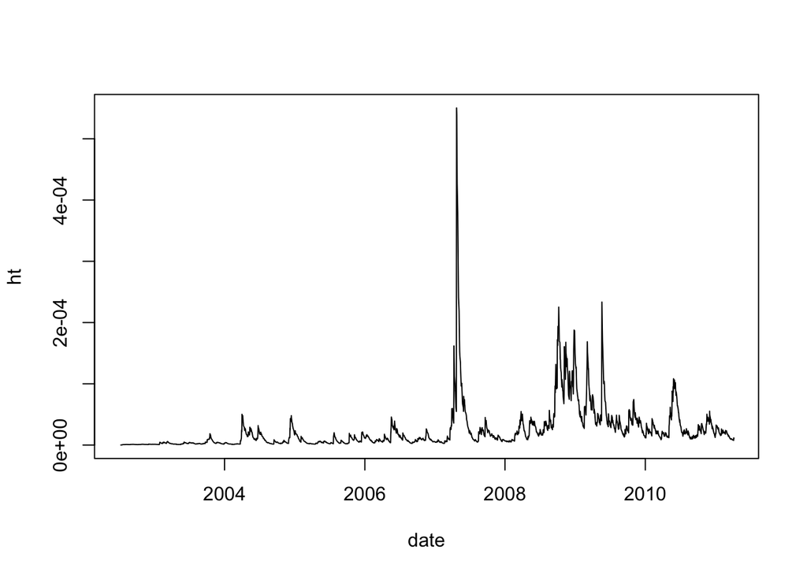

```r
plot(date, ht, type="l")
```

**Use this plot to locate bursts of high volatility.**

There is particularly high volatility in the beginning of 2007 and in late 2008 to early 2009.

**Do these highly volatile periods agree with those found from examination of the time series plot of the log exchange rates themselves?**

Yes, the time series plot varies more during these time periods.

## Problem 7

Here is a time series plot which simultaneously shows the log exchange rates, together with the ARIMA-ARCH one-step-ahead 95% forecast intervals based on information available in the previous day:

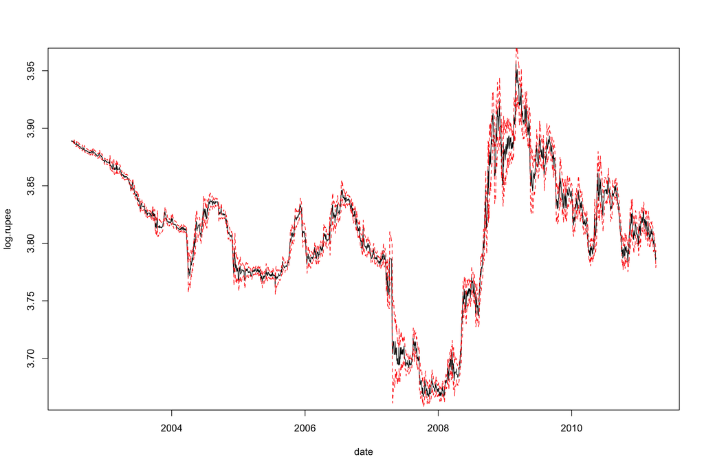

```r
plot(date, log.rupee, type="l")
lines(date, f + 1.96 * sqrt(ht), lty=2, col=2)
lines(date, f - 1.96 * sqrt(ht), lty=2, col=2)
```

**Using this plot, comment on the accuracy and practical usefulness of the forecast intervals.**

The forecast interval seems accurate. One nice practical feature is that the width is adaptive: the interval is wider in periods of high volatility, and narrower in periods of low volatility.

## Problem 8

Here is a normal probability plot of the ARCH residuals.

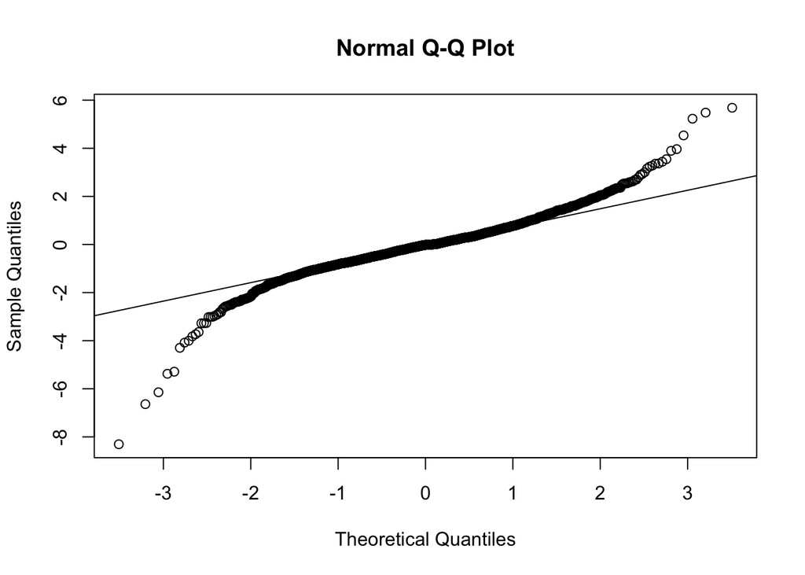

```r
resid.arch <- resid / sqrt(ht)
qqnorm(resid.arch)
qqline(resid.arch)
```

**Does the model seem to have adequately described the leptokurtosis (“long-tailedness”) in the data?**

The model is not capturing the leptokurtosis; the tails of the arch residuals are wider than those of a Gaussian random variable.

## Problem 9

Here is a count of how many prediction interval failures there were:

```r
sum(abs(resid.arch) > 1.96, na.rm=TRUE)
```

```
## [1] 113
```

The number of prediction intervals is:

```r
sum(!is.na(resid.arch))
```

```
## [1] 2229
```

**What percentage of the time did the intervals fail?

The proportion of intervals that failed was

```r
100 * (113 / 2229)
```

```
## [1] 5.069538
```

That is, the intervals failed roughly 5% of the time.